# 统计计算

Statistical Computing

Watthu

10/14/2022

# 随机数生成

# 有限总体抽样

在R中，对有限总体抽样直接采用`sample()`函数即可。例如：

```r
# toss some coins
sample(0:1, size = 10, replace = TRUE)
```

```
##  [1] 0 1 0 0 1 1 1 1 1 0
```

```r
# choose some lottery numbers
sample(1:100, size = 6, replace = FALSE)
```

```
## [1] 40 88 94 24 83 68
```

```r
# with weights (multinomial distribution)
sample(1:3, size = 20, replace = TRUE, prob = c(.2, .3, .5))
```

```
##  [1] 3 3 2 1 3 1 3 3 1 3 2 1 1 3 2 2 1 3 3 2
```

# 特殊分布抽样

对于概率论及数理统计中的常见分布，R中都有对应的函数生成相应分布的随机数。例如：

```r
# uniform(0, 1)
runif(10, 0, 1)
```

```
##  [1] 0.5090891 0.1393938 0.2248604 0.5139884 0.9806550 0.1280719 0.6811018
##  [8] 0.2558554 0.2511837 0.7512089
```

```r
# norm(1, 4)
rnorm(10, 1, 2)  # the second parameter is std
```

```
##  [1]  3.39977531 -2.90652412  0.49492431  0.86365552  0.62351409  0.04253066
##  [7] -1.51681038  1.54194874  1.17017534  2.43642928
```

对于其他分布，只需要在分布的缩写前加上`r`即可，例如`rpois`、`rf`、`rexp`等等。

# 逆变换法

根据概率论中的知识可知，如果随机变量 $X$ 具有分布函数 $F(x)$，那么 $U=F(X)\sim U(0,1)$。因此如果 $F_X^{-1}(U)$ 与 $X$ 同分布，所以逆变换法的步骤如下：

- 生成均匀随机变量 $U\sim U(0,1)$；
- 计算并返回 $X\sim F_X^{-1}(U)$ 即得相应分布随机变量。

例如：对
$$X\sim F(x)=\left\{\begin{array}{ll}
0, & x\leq0,\\ x^3, & 0<x\leq1,\\ 1, & x>1,
\end{array}\right.$$
只需利用如下代码就可以生成服从相应分布的随机数。

```r
n <- 1000   # sample size
u <- runif(n)
x <- u^{1/3}   # inverse of F
```

为了更加直观，下图给出了随机数直方图和概率密度函数的对比。

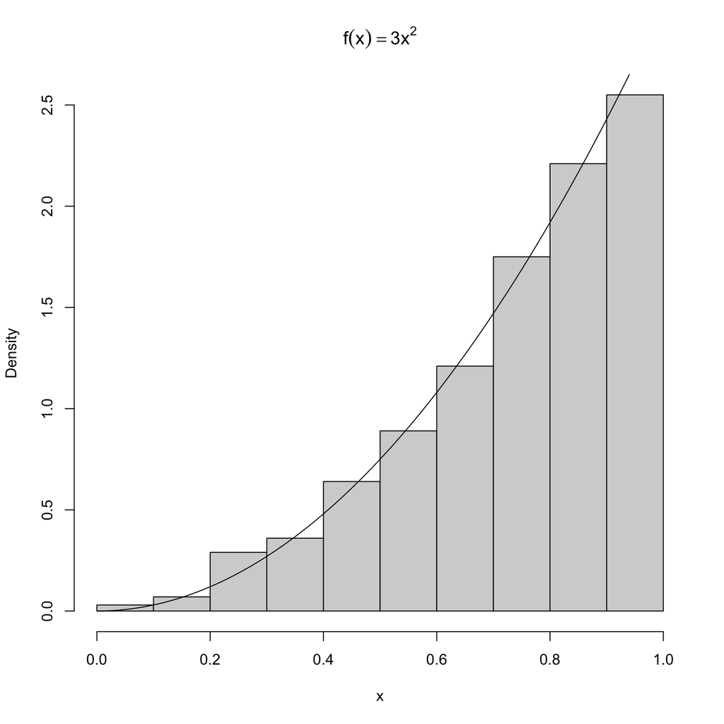

```r
hist(x, prob = TRUE, main = expression(f(x)==3*x^2))
y <- seq(0, 1, .01)
lines(y, 3*y^2)
```

# 逆变换法（Con’t）

上述方法适用于分布函数具有显式表达并且其逆便于计算的情形，而我们知道，对于离散型随机变量而言，这样的反函数通常采用广义反函数，即
$$F^{-1}(u)=\inf\{x:F(x)\geq u\}.$$

基于此，对离散型随机变量的逆变换算法如下：

- 生成均匀随机变量 $U\sim U(0,1)$；
- 如果 $F_X(x_{i-1})<U\leq F_X(x_i)$，则返回 $X=x_i$。

在实际问题中，我们通常先对概率进行累加，而随机数落在何区域，就取其右端点作为随机数的值。例如：对
$$X\sim\left(\begin{array}{cccc}
1 & 2 & 4 & 10\\
0.1 & 0.2 & 0.3 & 0.4
\end{array}\right)$$
产生随机数服从该分布。

```r
x <- c(1, 2, 4, 10)
p <- 1:4/10
cp <- cumsum(p)   # similar to calculating c.d.f.
n <- 1000   # sample size
u <- runif(n)
r <- x[findInterval(u, cp)+1]
```

下面这段代码是检验对应生成的随机数频率与概率是否一致。

```r
ct <- as.vector(table(r))
ct/sum(ct)/p
```

```
## [1] 0.950000 1.045000 1.006667 0.985000
```

输出结果中的4个值基本接近于1。

# 接受-拒绝法

接受-拒绝法的基本思想是用一个易于生成随机数的分布作为建议分布来近似实现目标密度函数的抽样。具体来说，分为以下几步：

- 选择简单函数 $g(x)$，满足 $f(x)\leq cg(x),~\forall x$；
- 根据 $g(x)$ 生成“建议随机数” $y$；
- 生成均匀分布随机数 $u\sim U(0,1)$；
- 如果 $u<\dfrac{f(y)}{cg(y)}$，则接受 $y$，并记 $x=y$，否则丢弃 $y$；
- 重复第2～4步直至样本量满足要求。

从理论上可以证明这样生成的随机数服从 $f(x)$ 对应的分布。事实上，
$$\begin{align*}
\mathbb P(X\leq x) &= \mathbb P\left(Y\leq x\mid U\leq\dfrac{f(Y)}{cg(Y)}\right)\\
&= \dfrac{\mathbb P\left(U\leq\dfrac{f(Y)}{cg(Y)},Y\leq x\right)}{\mathbb P\left(U\leq\dfrac{f(Y)}{cg(Y)}\right)}\\
&= \dfrac{\displaystyle\int_{-\infty}^x\mathbb P\left(U\leq\dfrac{f(Y)}{cg(Y)}\mid Y=y\right)g(y)\text{d}y}{\displaystyle\int_{-\infty}^{+\infty}\mathbb P\left(U\leq\dfrac{f(Y)}{cg(Y)}\mid Y=y\right)g(y)\text{d}y}\\
&= \dfrac{\displaystyle\int_{-\infty}^x\dfrac{f(y)}{cg(y)}g(y)\text{d}y}{\displaystyle\int_{-\infty}^{+\infty}\dfrac{f(y)}{cg(y)}g(y)\text{d}y}=F(x).
\end{align*}$$

在实际问题中，对于常数 $c$ 的选取是一个智慧，因为接受概率
$$\displaystyle\mathbb P(\text{接受})=\mathbb E[\mathbb P(\text{接受}\mid Y)]=\mathbb E\left[\dfrac{f(Y)}{cg(Y)}\right]=\dfrac{1}{c}<1.$$

如果 $c$ 越接近于 $1$，那么接受概率就越大，算法效率就越高。当然，最朴实的想法就是用均匀分布对之进行分布建议。

# 接受-拒绝法（Con’t）

例如：对 $X\sim\text{Beta}(2,2)$ 产生随机数服从该分布，其密度函数为
$$f(x)=6x(1-x)\pmb 1_{\{0<x<1\}};$$
可取均匀分布 $U(0,1)$ 作为建议分布，此时 $c=6$，代码如下。

```r
n <- 1000
k <- 0
x <- numeric(n)   # 首先生成一个n维的容器
while (k < n) {
    y <- runif(1)   # 生成建议分布随机数
    u <- runif(1)   # 这个随机数用于判断是否接受上面这个随机数
    if (y*(1-y) > u) {
        # 符合接受准则
        k <- k+1
        x[k] <- y
    }
}
```

我们可以用Q-Q图对产生的随机数服从的分布进行检验。

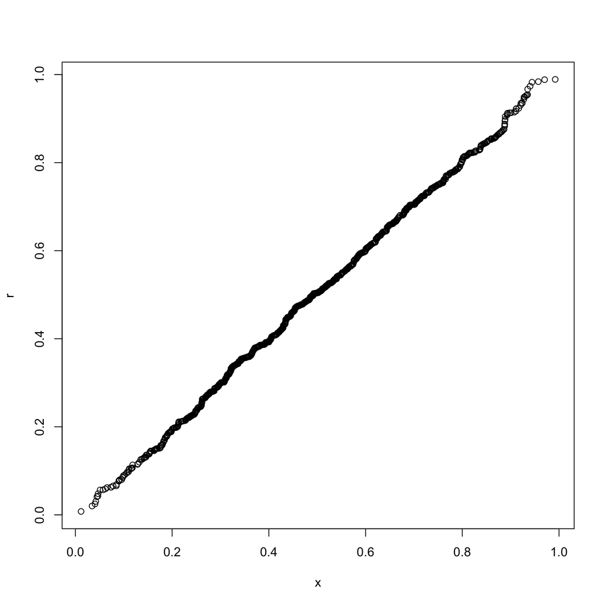

```r
r <- rbeta(1000, 2, 2)
qqplot(x, r)
```

# 随机变量的变换

根据Box-Muller变换，我们可以根据均匀随机变量得到正态变量，具体公式如下
$$\left\{\begin{array}{l}
Z_1=\sqrt{-2\log U}\cos(2\pi V),\\
Z_2=\sqrt{-2\log U}\sin(2\pi V),
\end{array}\right.$$
其中 $U,V\sim U(0,1)$。这样得到的 $Z_1,Z_2$ 是独立的标准正态变量。

有了标准正态变量之后，统计中的三大分布就有了落脚点，因为他们都是从标准正态分布中导出的。不过在实际运用中，我们更多还是采用R自带的随机数生成函数来得到相应分布的随机数。

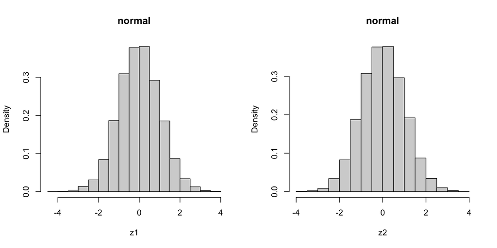

```r
n <- 10000
u <- runif(n)
v <- runif(n)
z1 <- sqrt(-2*log(u))*cos(2*pi*v)
z2 <- sqrt(-2*log(u))*sin(2*pi*v)
par(mfrow = c(1,2))
hist(z1, prob = TRUE, main = 'normal')
hist(z2, prob = TRUE, main = 'normal')
```

```r
cor(z1, z2)
```

```
## [1] 0.007520804
```

代码得到的二者的相关系数接近于0，也就意味着两个正态随机变量相互独立。

# 混合模型

设 $X_1\sim F_1(x)$，$X_2\sim F_2(x)$，现希望生成混合模型 $Y\sim 0.5F_1(x)+0.5F_2(x)$ 的随机数，一般情况下，显然不能使用上述方法进行模拟生成，需要考虑混合生成。例如：考虑两个卡方分布的混合模型。

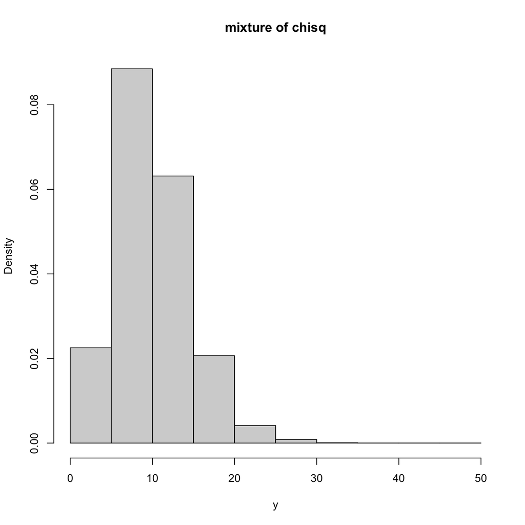

```r
n <- 10000
x1 <- rchisq(n, 5)
x2 <- rchisq(n, 10)
r <- sample(c(0, 1), replace = TRUE)
y <- r*x1 + (1-r)*x2
hist(y, prob = TRUE, main = 'mixture of chisq')
```

如果二者的混合比例不是相等的，则可以在生成两点分布时指定对应的成功概率。

# 贝叶斯模型

在贝叶斯统计推断中，参数具有一先验分布，而已知参数条件下，总体具有分布，通常我们需要生成总体的样本，则需要求出总体的边际分布，但这在大部分情况下不容易计算，因此考虑贝叶斯模型（实际上是贝叶斯统计推断中的分层先验模型）来生成随机数。

例如：设 $X\mid\Lambda\sim\text{Poisson}(\Lambda)$，而 $\Lambda\sim\text{Gamma}(r,\beta)$，可以通过如下代码生成 $X$ 的边际分布随机数。

```r
n <- 10000
r <- 4
beta <- 3
lambda <- rgamma(n, r, beta)
x <- rpois(n, lambda)
```

当然，对于这个例子来说，$X$ 的边际分布是参数为 $r$ 和 $p=\dfrac{\beta}{1+\beta}$ 的负二项分布。事实上，
$$\begin{align*}
f(x) &= \displaystyle\int_0^{+\infty}f(x\mid\lambda)\pi(\lambda)\text{d}\lambda\\
&= \displaystyle\int_0^{+\infty}\frac{\lambda^x}{x!}\text{e}^{-\lambda}\cdot\frac{\beta^r}{\Gamma(r)}\lambda^{r-1}\text{e}^{-\beta\lambda}\text{d}\lambda\\
&= \displaystyle\dfrac{\beta^r}{x!\Gamma(r)}\int_0^{+\infty}\lambda^{x+r-1}\text{e}^{-\lambda(\beta+1)}\text{d}\lambda\\
&= \displaystyle\dfrac{\beta^r}{x!\Gamma(r)}\dfrac{\Gamma(x+r)}{(\beta+1)^{x+r}}=\binom{x+r-1}{r-1}p^r(1-p)^x,\quad x=0,1,\dots.
\end{align*}$$

因此我们直接从负二项分布中进行采样，看看两种算法的效果差异。

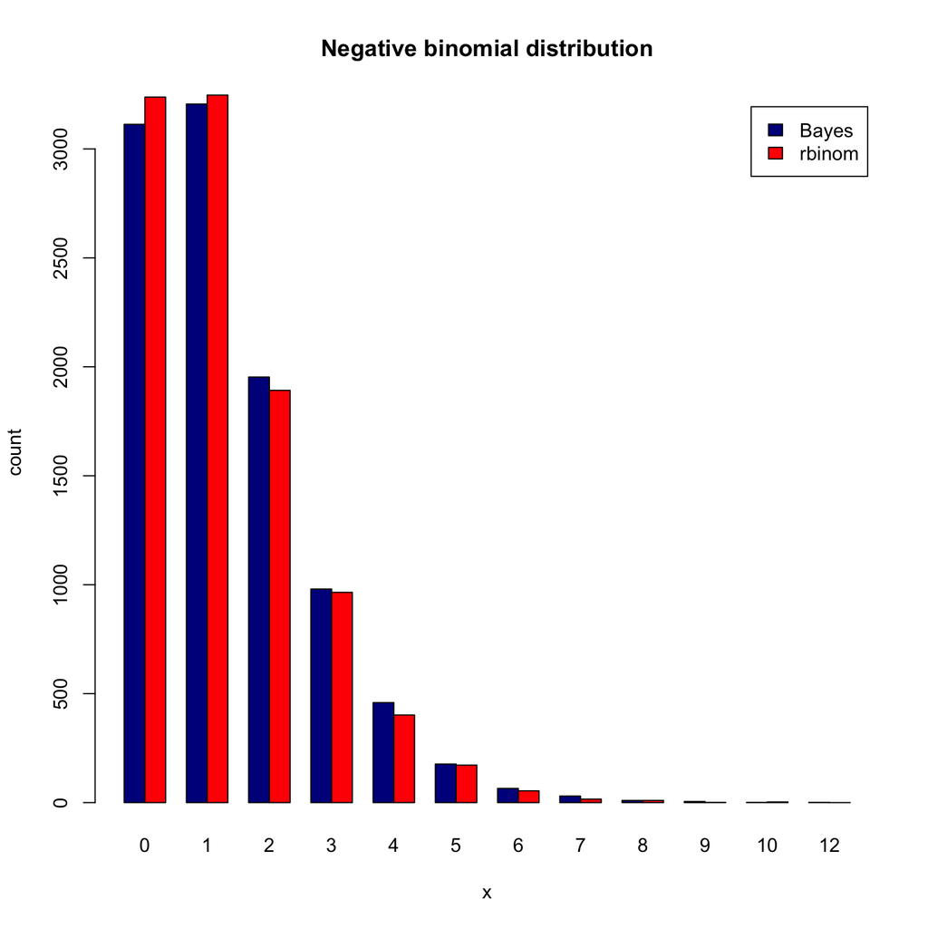

```r
y <- rnbinom(n, r, beta/(1+beta))
counts <- table(c(rep(0, n), rep(1, n)), c(x, y))
barplot(counts, main = 'Negative binomial distribution',
        xlab = 'x', ylab = 'count', col = c('darkblue', 'red'),
        legend = c('Bayes', 'rbinom'), beside = TRUE)
```

# 多元正态分布的随机数生成

对于协方差矩阵为单位矩阵的多元正态随机向量的随机数生成是容易的，但是如果要求不同分量之间的协方差（或相关系数）各异，则需要利用协方差矩阵的特征值分解来实现。具体算法如下：

- 计算协方差矩阵 $\pmb\Sigma$ 的特征值和特征向量，作特征分解 $\pmb\Sigma=\pmb V\pmb\Lambda\pmb V^{\textsf{T}}$；
- 计算变换矩阵 $\pmb C=\pmb V\pmb\Lambda^{1/2}\pmb V^{\textsf{T}}$；
- 生成标准正态随机向量 $\pmb Z$；
- 生成一般正态随机向量 $\pmb Y=\pmb\mu+\pmb C\pmb Z$。

由此得到的 $\pmb Y$ 服从多元正态分布 $MVN(\pmb\mu,\pmb\Sigma)$。

```r
rmvn.eigen <- function(n, mu, Sigma) {
  d <- length(mu)
  ev <- eigen(Sigma, symmetric = TRUE)
  lambda <- ev$values
  V <- ev$vectors
  C <- V %*% diag(sqrt(lambda)) %*% t(V)
  Z <- matrix(rnorm(n*d), nrow = n, ncol = d)
  Y <- Z %*% C + matrix(mu, n, d, byrow = TRUE)
  return(Y)
}

mu <- c(0, 1)
Sigma <- matrix(c(1, .8, .8, 2), nrow = 2, ncol = 2)
X <- rmvn.eigen(5000, mu, Sigma)
cov(X)
```

```
##           [,1]      [,2]
## [1,] 1.0101752 0.7978306
## [2,] 0.7978306 1.9777148
```

由样本计算得到的协方差矩阵估计为 $\hat{\pmb\Sigma}=\left(\begin{array}{cc} 1.0101752 & 0.7978306\\ 0.7978306 & 1.9777148 \end{array}\right)$，这与真实参数基本一致，随机向量的分布图如下。

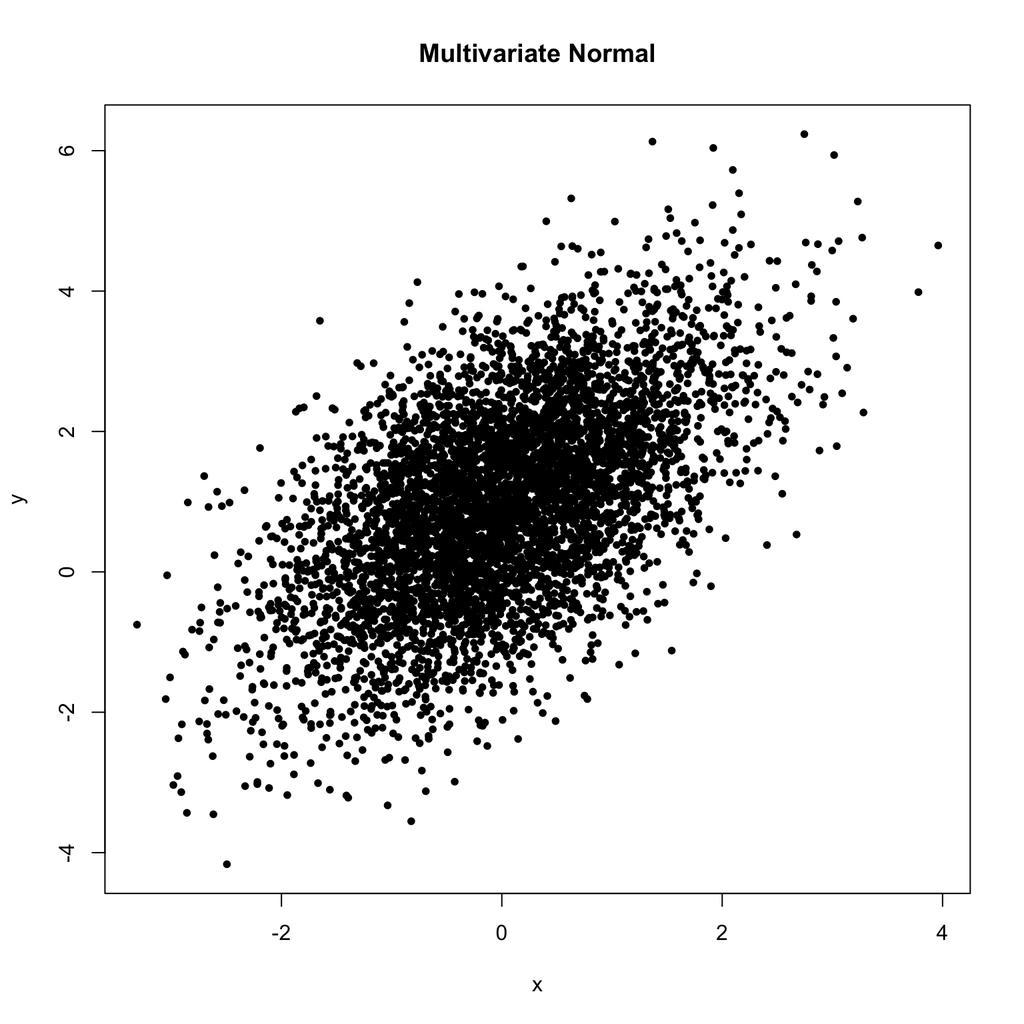

```r
plot(X, main = 'Multivariate Normal', xlab = 'x', ylab = 'y', pch = 20)
```

# 蒙特卡洛积分

# Buffon投针问题

平面上画有很多平行线，其间距为 $a$。现向此平面投掷长为 $l$ $(l<a)$ 的针，则针的位置可以由两个数决定：针的中点与最接近的平行线之间的距离 $x$ 和针与平行线的夹角 $\varphi$，则样本空间为
$$\Omega=\left\{(\varphi,x)\mid 0\leq\varphi\leq\pi,0\leq x\leq\dfrac{a}{2}\right\}.$$
所感兴趣的事件“针与平行线相交”对应的区域为
$$g=\left\{(\varphi,x)\mid x\leq\dfrac{l}{2}\sin\varphi\right\}.$$
因此，针与任一平行线相交的概率为
$$P=\dfrac{\vert g\vert}{\vert\Omega\vert}=\dfrac{\displaystyle\int_0^\pi\dfrac{l}{2}\sin\varphi\text{d}\varphi}{\pi(a/2)}=\dfrac{2l}{a\pi}.$$

这一问题可以用来估计 $\pi$ 的近似值。方法是重复投针 $N$ 次，统计与平行线相交的次数 $n$，则根据频率与概率的关系可知，当 $N$ 足够大时，
$$\dfrac{2l}{a\pi}=P\approx\dfrac{n}{N}~\Rightarrow~\pi\approx\dfrac{2lN}{an}.$$

对应的R代码如下：

```r
a <- 2
l <- 1
N <- 100000
x <- runif(N, 0, a/2)
phi <- runif(N, 0, pi)
pihat <- 2*l/a/mean(l*sin(phi)/2>x)
pihat
```

```
## [1] 3.148317
```

可见结果与真实的圆周率的值十分接近。

设计一个随机试验，通过大量重复试验得到某种结果，以确定我们感兴趣的量，由此发展而成了著名的蒙特卡洛（Monte-Carlo）方法。

# 简易蒙特卡洛估计

现在我们感兴趣的问题是要计算定积分 $\displaystyle\int_a^b f(x)\text{d}x$. 可以有几种做法：

- 分析方法（微积分）：具有局限性；
- 数值积分：对一维情形较容易；
- 蒙特卡洛方法：具有普适应用。

蒙特卡洛方法的想法就是利用样本均值代替总体均值，即
$$\displaystyle \int_a^b f(x)\text{d}x=\int_a^b g(x)\dfrac{1}{b-a}\text{d}x=\mathbb E[g(X)]\approx\dfrac{1}{m}\sum_{i=1}^m g(X_i),$$
其中 $X\sim U(a,b)$，$g(x)=(b-a)f(x)$，$X_1,\dots,X_m$ i.i.d. $\sim U(a,b)$，而 $m$ 是一个充分大的正整数。

例如，要计算
$$\displaystyle\theta=\int_2^4\text{e}^{-x}\text{d}x=2\mathbb E(\text{e}^{-X}),\quad X\sim U(2,4),$$
可依赖如下MC代码实现：

```r
m <- 100000
x <- runif(m, 2, 4)
thetahat <- mean(exp(-x))*2
thetahat
```

```
## [1] 0.1173191
```

而积分的真值为 $\text{e}^{-2}-\text{e}^{-4}=0.1170196$，可见十分接近。

# 简易蒙特卡洛估计（Con’t）

再如，要计算
$$\displaystyle\theta=\int_0^x\text{e}^{-\frac{t^2}{2}}\text{d}t=\mathbb E_Y\big[x\text{e}^{-\frac{Y^2}{2}}\big],\quad Y\sim U(0,x),$$

可依赖如下MC代码实现：

```r
m <- 100000
x <- 1
y <- runif(m, 0, x)
thetahat <- mean(x*exp(-y^2/2))
thetahat
```

```
## [1] 0.85622
```

而积分的真值为 $\sqrt{2\pi}(\Phi(1)-0.5)=0.8556244$，可见十分接近。

# 理论性质

考虑蒙特卡洛积分估计的一般情形，即
$$\displaystyle\theta=\int_Af(x)\text{d}x=\int_Ag(x)h(x)\text{d}x=\mathbb E_X[g(X)],$$
其中 $X$ 是在支撑 $A$ 上具有 p.d.f./p.m.f. $h(x)$ 的随机变量。蒙特卡洛积分估计为
$$\displaystyle\hat{\theta}=\dfrac{1}{m}\sum_{i=1}^mg(X_i),$$
其中 $X_1,\dots,X_m$ i.i.d. $\sim h(x)$。

不难证明 $\hat{\theta}$ 是无偏估计、相合估计，而它的方差为 $\dfrac{1}{m}\text{Var}[g(X_1)]$，它的估计为
$$\displaystyle\hat{\sigma}_m^2=\dfrac{1}{m(m-1)}\sum_{i=1}^m(g(x_i)-\overline{g(x)})^2,$$
其中 $\displaystyle\overline{g(x)}=\frac{1}{m}\sum_{i=1}^mg(x_i)$。进而可以给出 $\theta$ 的近似置信区间等。

例如，在上例中，可以进一步计算

```r
thetas <- x*exp(-y^2/2)
se <- sd(thetas)/sqrt(m)
c(thetahat - 1.96*se, thetahat + 1.96*se)
```

```
## [1] 0.8554679 0.8569721
```

此即 $\theta$ 的水平为 95% 的近似置信区间。

# 方差缩减

为了提高蒙特卡洛估计的准确性，我们希望降低 $\hat{\theta}$ 的方差，当然我们可以通过增大样本量来实现这一功能，但一般地，我们还是希望能够减少 $\text{Var}[g(X_1)]$ 的值。

# 对偶变量

设 $U_1$ 和 $U_2$ 均为 $\theta$ 的无偏估计量，而且负相关，则 $(U_1+U_2)/2$ 也是 $\theta$ 的无偏估计量，且方差
$$\text{Var}\left(\dfrac{U_1+U_2}{2}\right)=\dfrac{\text{Var}(U_1)+\text{Var}(U_2)+\text{Cov}(U_1,U_2)}{4}<\dfrac{\text{Var}(U_1)+\text{Var}(U_2)}{4}.$$

不妨设 $\text{Var}(U_1)=\text{Var}(U_2)$，则如果分别用 $X_1,\dots,X_{m/2}$ (i.i.d.) 和 $Y_1,\dots,Y_{m/2}$ (i.i.d.) 来计算 $U_1$ 和 $U_2$ 的值，并且 $U_1$ 和 $U_2$ 是负相关的，那么 $(U_1+U_2)/2$ 的方差会小于用 $X_1,\dots,X_{m/2},X_{m/2+1},\dots,X_m$ (i.i.d.) 来计算的估计量的方差，这就实现了方差缩减的功能。

在实际应用中，如果要求生成的均匀随机变量来自 $U(a,b)$，我们常常考虑基于 $U$ 和 $a+b-U$ 来得到积分的（方差更小的）估计。

例如，在上面第二个例子中，我们可以考虑前 $m/2$ 部分由 $Y\sim U(0,x)$ 产生，而后 $m/2$ 部分由 $x-Y$ 产生（这里的 $Y$ 是刚刚产生的随机数），即
$$\displaystyle\hat{\theta}'=\dfrac{1}{m}\sum_{i=1}^{m/2}\big[x\text{e}^{-\frac{U_i^2}{2}}+x\text{e}^{-\frac{(x-U_i)^2}{2}}\big],\quad U_i\sim U(0,x).$$

参看下述代码：

```r
MCtheta <- function(x, R = 1000, antithetic = TRUE) {
  u <- runif(R/2,0,x)
  if (!antithetic) v <- runif(R/2,0,x) else v <- x - u
  y <- c(u, v)
  thetahat <- mean(x*exp(-y^2/2))
  return(thetahat)
}
m <- 1000
MC1 <- MC2 <- numeric(m)
x <- 1
for (i in 1:m) {
  MC1[i] <- MCtheta(x, R = 1000, anti = FALSE)
  MC2[i] <- MCtheta(x, R = 1000)
}
c(sd(MC1), sd(MC2), sd(MC2)/sd(MC1))
```

```
## [1] 0.004006347 0.001051862 0.262548912
```

从最后一个值中可以看到，采用对偶变量法大大减少了估计量的方差。

# 控制变量

注意到如果 $g(X)$ 是 $\theta$ 的一个无偏估计量，那么
$$g(X)+c\big(f(X)-\mathbb E[f(X)]\big)$$
也是 $\theta$ 的无偏估计量，这里 $c$ 是一个常数，而 $f(x)$ 是任意期望存在且有限的函数。

可以计算得到该估计量方差最小时对应的 $c^\star$ 为
$$\displaystyle c^\star=-\dfrac{\text{Cov}(g(X),f(X))}{\text{Var}(f(X))},$$
对应的最小方差为
$$\text{Var}[g(X)][1-{\rm Corr}^2(g(X),f(X))].$$

由此可以实现方差缩减。但是需要注意以下几个问题：

- $\mathbb E[f(X)]$ 需要有显式表达，否则无偏估计量的形式无法得到；
- 当且仅当 $f(X)$ 和 $g(X)$ 相关时，这种方法才有效，而且强相关情况下，方差缩减的性能更佳。
- $c^\star$ 的值可以分析计算也可以数值计算。

例如，要计算 $\displaystyle\theta=\mathbb E(\text{e}^U)=\int_0^1\text{e}^u\text{d}u$，考虑控制函数 $f(U)=U$（$\text{e}^U$ 在 $U=0$ 处的一阶Taylor展开），于是
$$\displaystyle\mathbb E[f(U)]=0.5,\quad c^\star=-\frac{\text{Cov}(\text{e}^U,U)}{\text{Var}(U)}=6\text{e}-18.$$

不难计算得
$$\displaystyle\text{Var}[g(U)]\approx0.242,\quad\text{Var}[g(U)-c^\star(U-0.5)]\approx0.00394.$$

理论上看，方差得到了很大程度上的缩减。下面用代码验证之。

```r
m <- 100000
cstar <- 6*exp(1)-18
U <- runif(m)
T1 <- exp(U)
T2 <- exp(U) + cstar*(U - 0.5)
c(mean(T1), mean(T2), exp(1)-1)
```

```
## [1] 1.718324 1.718309 1.718282
```

可以看到控制变量的方法得到的结果更接近真值。

```r
c(var(T1), var(T2), (var(T1)-var(T2))/var(T1))
```

```
## [1] 0.242358902 0.003929551 0.983786233
```

而方差也是控制变量的结果更小，跟理论值一致，而方差也是缩减了98.37%之多。

```r
cor(T1, U)
```

```
## [1] 0.9918603
```

可见 $f(U)$ 和 $g(U)$ 之间的相关性很强。

# 控制变量（Con’t）

下面这个例子是 $c^\star$ 不容易分析计算而要采用数值计算的情况。

要计算 $\displaystyle\theta=\mathbb E\Big(\frac{\text{e}^{-U}}{1+U^2}\Big)=\int_0^1\frac{\text{e}^{-u}}{1+u^2}\text{d}u$，考虑控制函数 $f(U)=\dfrac{\text{e}^{-0.5}}{1+U^2}$，于是
$$\mathbb E[f(U)]=\text{e}^{-0.5}\pi/4,$$
而 $c^\star$ 的值需要数值计算。参看如下代码：

```r
f <- function(u) exp(-0.5)/(1+u^2)
g <- function(u) exp(-u)/(1+u^2)
u <- runif(10000)
cstar <- - cov(f(u), g(u)) / var(f(u))
m <- 100000
u <- runif(m)
T1 <- g(u)
T2 <- g(u) + cstar * (f(u) - exp(-0.5)*pi/4)
c(mean(T1), mean(T2))
```

```
## [1] 0.5245750 0.5249113
```

故积分的真值应约为`0.524`。

```r
c(var(T1), var(T2), (var(T1)-var(T2))/var(T1))
```

```
## [1] 0.06011253 0.00309848 0.94845533
```

可见方差缩减了94.85%之多。

# 重要性采样

回到蒙特卡洛积分的一般情形，即
$$\displaystyle\theta=\int_Ag(x)\text{d}x=\int_A\frac{g(x)}{f(x)}f(x)\text{d}x=\mathbb E_X\Big[\frac{g(X)}{f(X)}\Big],$$
其中 $X$ 是在支撑 $A$ 上具有 p.d.f./p.m.f. $f(x)$ 的随机变量。蒙特卡洛积分估计为
$$\displaystyle\hat{\theta}=\dfrac{1}{m}\sum_{i=1}^m\frac{g(X_i)}{f(X_i)},$$
其中 $X_1,\dots,X_m$ i.i.d. $\sim f(x)$。

前面所讲述的方法都取了 $f(x)$ 为对应支撑上的均匀分布，也就是说将所有的都赋予相同的权重，但这有时候在计算时效率不是很高，这从前面两种方差缩减方法中也可以看出来。

重要性采样的思想是用一个十分接近 $g(x)$ 且容易采样的概率密度函数 $f(x)$ 来进行重要性采样，这种估计的方差
$$\displaystyle\text{Var}(\hat{\theta})=\frac{1}{m}\text{Var}\Big[\frac{g(X_1)}{f(X_1)}\Big]$$
在 $g(\cdot)=cf(\cdot)$ 对某个常数 $c$ 成立时达到最小值0，这里的 $f(\cdot)$ 称为 $g(\cdot)$ 的重要性函数。

同样考虑上例中的积分 $\displaystyle\theta=\int_0^1\frac{\text{e}^{-x}}{1+x^2}\text{d}x$，考虑以下几个重要性函数：

$$\begin{align*}
f_0(x) &= 1,\quad 0<x<1,\\
f_1(x) &= \text{e}^{-x},\quad 0<x<\infty,\\
f_2(x) &= \dfrac{1}{\pi(1+x^2)},\quad -\infty<x<\infty,\\
f_3(x) &= \dfrac{\text{e}^{-x}}{1-\text{e}^{-1}},\quad 0<x<1,\\
f_4(x) &= \dfrac{4}{\pi(1+x^2)},\quad 0<x<1.
\end{align*}$$

记被积函数为 $g(x)=\dfrac{\text{e}^{-x}}{1+x^2},0<x<1$，先在同一坐标系中画出 0～1 范围内各自的函数图像比较。

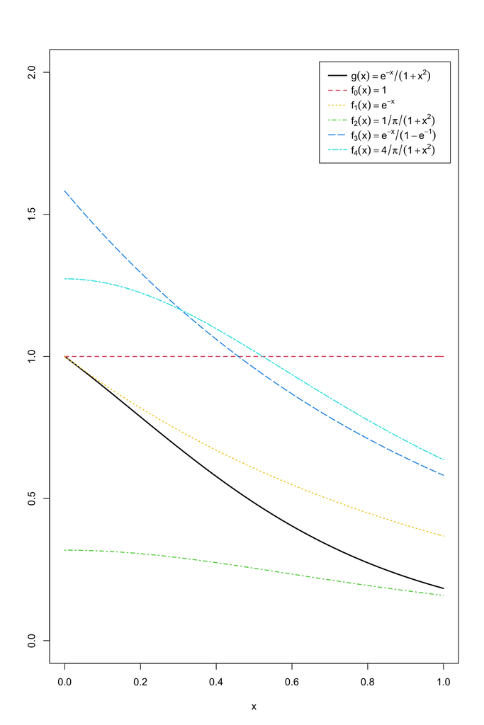

```r
x <- seq(0, 1, 0.01)
g <- exp(-x) / (1+x^2)
f0 <- replicate(length(x), 1)
f1 <- exp(-x)
f2 <- 1 / (1+x^2) / pi
f3 <- exp(-x) / (1 - exp(-1))
f4 <- 4 / (1+x^2) / pi

plot(x, g, type = 'l', xlab='x', ylab='', xlim=c(0,1), ylim=c(0,2), lwd=2)
lines(x, f0, col=2, lty=2, lwd=1.5)
lines(x, f1, col=7, lty=3, lwd=1.5)
lines(x, f2, col=3, lty=4, lwd=1.5)
lines(x, f3, col=4, lty=5, lwd=1.5)
lines(x, f4, col=5, lty=6, lwd=1.5)
legend("topright", c(expression(g(x)==e^{-x}/(1+x^2)),
                     expression(f[0](x)==1),
                     expression(f[1](x)==e^{-x}),
                     expression(f[2](x)==1/pi/(1+x^2)),
                     expression(f[3](x)==e^{-x}/(1-e^{-1})),
                     expression(f[4](x)==4/pi/(1+x^2))),
       col=c(1, 2, 7, 3, 4, 5), lty=c(1, 2, 3, 4, 5, 6), lwd=c(2, 1.5, 1.5, 1.5, 1.5, 1.5),
       x.intersp=0.5, y.intersp=1.2, inset = 0.02, bty = 'o', text.width=0.25)
```

```r
m <- 10000
thetahat <- se <- numeric(5)
g <- function(x) {exp(-x) / (1+x^2) * (x>0) * (x<1)}

x <- runif(m)  # f0
gf <- g(x)
thetahat[1] <- mean(gf)
se[1] <- sd(gf)

x <- rexp(m, 1) # f1
gf <- 1/(1+x^2) * (x<1)
thetahat[2] <- mean(gf)
se[2] <- sd(gf)

x <- rcauchy(m) # f2
x <- x * (x>0) * (x<1) # Note the range of x
gf <- pi * exp(-x) * (x>0) * (x<1)
thetahat[3] <- mean(gf)
se[3] <- sd(gf)

u <- runif(m) # f3
x <- - log(1 - u * (1 - exp(-1)))
gf <- (1 - exp(-1)) / (1 + x^2)
thetahat[4] <- mean(gf)
se[4] <- sd(gf)

u <- runif(m) # f4
x <- tan(pi * u / 4)
gf <- pi * exp(-x) / 4
thetahat[5] <- mean(gf)
se[5] <- sd(gf)

rbind(thetahat, se)
```

```
              [,1]      [,2]      [,3]       [,4]      [,5]
thetahat 0.5244408 0.5222454 0.5314499 0.52238411 0.5219405
se       0.2448230 0.4191902 0.9571161 0.09783582 0.1405660
```

可以看到，用与目标函数形式较一致的重要性函数所最终得到的结果更加精确，标准差也更小。

# 分层采样

考虑将 $M$ 个样本分层为 $k$ 层，每层样本数为 $m_i~(i=1,\dots,k)$，考虑分层估计量
$$\displaystyle\hat{\theta}^S=\sum_{i=1}^kw_i\hat{\theta}_i$$
其中每一层的采用MC估计 $\hat{\theta}_i$，$w_i$ 是每一层的权重。不难证明 $\text{Var}(\hat{\theta}^S)\leq\text{Var}(\hat{\theta}^M)$，这里 $\hat{\theta}^M$ 是直接采用 $M$ 个样本做的简单MC估计。

**命题.** 记 $\displaystyle\hat{\theta}^M=\frac{1}{M}\sum_{i=1}^Mg(U_i)$ 为直接采用 $M$ 个样本做的简单MC估计，$\displaystyle\hat{\theta}^S=\frac{1}{k}\sum_{j=1}^k\hat{\theta}_j$ 为分层估计量（这里假设均匀分层，即 $m=M/k$），其中 $\displaystyle\hat{\theta}_j=\frac{1}{m}\sum_{i=1}^mg(U_{ji})$。于是
$$\displaystyle\text{Var}(\hat{\theta}^S)=\frac{1}{k^2}\sum_{j=1}^k\text{Var}(\hat{\theta}_j)=\frac{1}{k^2}\sum_{j=1}^k\frac{1}{m}\sigma_j^2=\frac{1}{Mk}\sum_{j=1}^k\sigma_j^2.$$

另外，设 $J$ 是随机选择的层，它服从概率为 $1/k$ 的离散均匀分布，于是

$$\begin{align*}
\text{Var}(\hat{\theta}^M) &= \frac{\text{Var}(g(U))}{M}=\frac{1}{M}\big[\text{Var}(\mathbb E[g(U)\mid J])+\mathbb E[\text{Var}(g(U)\mid J)]\big]\\
&= \frac{1}{M}\big(\text{Var}(\theta_J)+\mathbb E(\sigma_J^2)\big)\\
&= \frac{1}{M}\left(\text{Var}(\theta_J)+\frac{1}{k}\sum_{j=1}^k\sigma_j^2\right)\\
&= \dfrac{1}{M}\text{Var}(\theta_J)+\text{Var}(\hat{\theta}^S)\geq\text{Var}(\hat{\theta}^S).
\end{align*}$$

# 分层采样（Con’t）

同样考虑上例中的积分 $\displaystyle\theta=\int_0^1\frac{\text{e}^{-x}}{1+x^2}\text{d}x$，注意到

$$\begin{align*}
\displaystyle\int_0^1\frac{\text{e}^{-x}}{1+x^2}\text{d}x &= \displaystyle\sum_{i=1}^k\int_{(i-1)/k}^{i/k}\frac{\text{e}^{-x}}{1+x^2}\text{d}x\\
&= \displaystyle\frac{1}{k}\sum_{i=1}^k\int_{(i-1)/k}^{i/k}\frac{\text{e}^{-x}}{1+x^2}k\text{d}x\\
&= \displaystyle\dfrac{1}{k}\sum_{i=1}^k\mathbb E\left(\frac{\text{e}^{-X_i}}{1+X_i^2}\right),\quad X_i\sim U\left(\frac{i-1}{k},\frac{i}{k}\right).
\end{align*}$$

因此，分层采样的代码实现如下：

```r
M <- 10000
k <- 10
m <- M / k
N <- 100
T2 <- numeric(k)
est <- matrix(0, N, 2)
g <- function(x) {
  exp(-x)/(1+x^2) * (x>0) * (x<1)
}
for (i in 1:N) {
  est[i, 1] <- mean(g(runif(M)))
  for (j in 1:k) {
    T2[j] <- mean(g(runif(m, (j-1)/k, j/k)))
  }
  est[i, 2] <- mean(T2)
}
mu = apply(est, 2, mean)
se = apply(est, 2, sd)
rbind(mu, se)
```

```
          [,1]         [,2]
mu 0.524634505 0.5248147087
se 0.002497914 0.0002841443
```

可见分层采样的方差比简单MC方法的方差要小得多。

# 统计推断中的蒙特卡洛方法

# 点估计问题

设 $\hat{\theta}(X_1,\dots,X_n)$ 是未知参数 $\theta$ 的估计量，关心以下问题：

- 这个估计的偏差（Bias）$\hat{\theta}-\theta$ 是多少？
- 这个估计的标准误差（SE）$\text{se}(\hat{\theta})$ 是多少？（对它而言，这个值越小越好）
- 这个估计的标准误差的估计（SEE）$\hat{\text{se}}(\hat{\theta})$ 是多少？（为进一步构建置信区间、做假设检验提供帮助）

一般地，我们考虑做 $m$ 次估计，来得到 $\hat{\theta}_1,\dots,\hat{\theta}_m$，基于此构建上述估计。具体算法如下：

- 设定随机种子、重复次数 $m$、样本量 $n$ 和参数真值 $\theta_0$；
- 对第 $j~(j=1,\dots,m)$ 次计算
  - 生成样本 $X_{j1},\dots,X_{jn}$；
  - 估计 $\theta$：$\hat{\theta}_j=\hat{\theta}(X_{j1},\dots,X_{jn})$ 及其标准误差 $\hat{\text{se}}_j=\hat{\text{se}}(\hat{\theta}_j)$；
- 计算相应的估计量：
  - 偏差 Bias $=\overline{\theta}-\theta_0$，其中 $\overline{\theta}=\dfrac{1}{m}\sum\limits_{j=1}^m\hat{\theta}_j$；
  - 标准误差 SE $=\sqrt{\dfrac{1}{m-1}\sum\limits_{j=1}^m(\hat{\theta}_j-\overline{\theta})^2}$；
  - 标准误差的估计 SEE $=\dfrac{1}{m}\sum\limits_{j=1}^m\hat{\text{se}}_j.$

一般情况下，即使方差估计是无偏的，但标准误差的估计不是标准误差的无偏估计，这是因为随机误差、试验设计、样本量等的影响。参考下面几个例子。

# 点估计问题（Con’t）

**例1. (正态误差、随机预测)** 对模型
$$Y_i=\alpha+\beta X_i+e,\quad e\sim N(0,1),~X_i\sim Exp(1).$$

考虑参数 $\beta$ 的最小二乘估计。

```r
alpha <- 2; beta <- 1
m <- 1000; n <- 10; set.seed(1)
beta.hat <- beta.se <- numeric(m)
for (i in 1:m) {
  x <- rexp(n)
  y <- alpha + beta*x + rnorm(n)
  coef <- summary(lm(y~x))$coef
  beta.hat[i] <- coef[2,1]
  beta.se[i] <- coef[2,2]
}
c(mean(beta.hat), sd(beta.hat), mean(beta.se))
```

```
## [1] 1.0006017 0.4940051 0.4201906
```

```r
c(var(beta.hat), mean(beta.se^2))
```

```
## [1] 0.2440410 0.2281339
```

# 点估计问题（Con’t）

**例2. (非正态误差、随机预测)** 对模型
$$Y_i=\alpha+\beta X_i+e,\quad e\sim ST(\alpha=8,\nu=2),~X_i\sim Exp(1).$$

考虑参数 $\beta$ 的最小二乘估计。

```r
alpha <- 2; beta <- 1
m <- 1000; n <- 10; set.seed(1)
beta.hat <- beta.se <- numeric(m)
for (i in 1:m) {
  x <- rexp(n)
  y <- alpha + beta*x + sn::rst(n, alpha=8, nu=2)
  coef <- summary(lm(y~x))$coef
  beta.hat[i] <- coef[2,1]
  beta.se[i] <- coef[2,2]
}
c(mean(beta.hat), sd(beta.hat), mean(beta.se))
```

```
## [1] 1.0329123 1.1641705 0.7988274
```

```r
c(var(beta.hat), mean(beta.se^2))
```

```
## [1] 1.355293 5.512689
```

# 点估计问题（Con’t）

考虑参数 $\beta$ 的最小二乘估计。

```r
alpha <- 2; beta <- 1
m <- 1000; n <- 10; set.seed(1)
beta.hat <- beta.se <- numeric(m)
x <- rexp(n)
for (i in 1:m) {
  y <- alpha + beta*x + rnorm(n)
  coef <- summary(lm(y~x))$coef
  beta.hat[i] <- coef[2,1]
  beta.se[i] <- coef[2,2]
}
c(mean(beta.hat), sd(beta.hat), mean(beta.se))
```

```
## [1] 0.9882903 0.4014756 0.3853365
```

```r
c(var(beta.hat), mean(beta.se^2))
```

```
## [1] 0.1611826 0.1583228
```

# 点估计问题（Con’t）

**例4. (非正态误差、固定预测)** 对模型
$$Y_i=\alpha+\beta X+e,\quad e\sim ST(\alpha=8,\nu=2),~X\sim Exp(1).$$

考虑参数 $\beta$ 的最小二乘估计。

```r
alpha <- 2; beta <- 1
m <- 1000; n <- 10; set.seed(1)
beta.hat <- beta.se <- numeric(m)
x <- rexp(n)
for (i in 1:m) {
  y <- alpha + beta*x + sn::rst(n, alpha=8, nu=2)
  coef <- summary(lm(y~x))$coef
  beta.hat[i] <- coef[2,1]
  beta.se[i] <- coef[2,2]
}
c(mean(beta.hat), sd(beta.hat), mean(beta.se))
```

```
## [1] 1.0056361 1.8029219 0.7475751
```

```r
c(var(beta.hat), mean(beta.se^2))
```

```
## [1] 3.250527 5.934975
```

# 点估计问题（Con’t）

在估计量的评价准则中，还有一个十分常用的标准，那就是均方误差MSE：
$$\text{MSE}=\mathbb E(\hat{\theta}-\theta)^2=\text{Var}(\hat{\theta})+(\mathbb E(\hat{\theta})-\theta)^2=\text{Variance}+\text{Bias}^2.$$

对它的估计可以采用 $\dfrac{1}{m}\sum\limits_{j=1}^m(\hat{\theta}_j-\theta)^2$。例如，在例4中，可以进一步计算MSE的估计如下：

```r
mean((beta.hat-beta)^2)
```

```
## [1] 3.247309
```

这个值和它的方差3.2505273十分接近，因为在最小二乘估计中 $\hat{\beta}$ 是 $\beta$ 的无偏估计，那么MSE就是方差。

# 区间估计问题

在经典统计推断区间估计问题中，我们感兴趣的是重复试验下区间估计的**覆盖概率（Coverage Probability）**：如果 $\theta$ 的 $(1-\alpha)\%$ 置信区间为 $(\hat{\theta}_L,\hat{\theta}_U)$，那么覆盖概率定义为 $\mathbb P(\hat{\theta}_L<\theta<\hat{\theta}_U)$。（注意，在经典统计推断中，这里随机变量是 $\hat{\theta}_L$ 和 $\hat{\theta}_U$）

我们希望一个好的区间估计有接近于 $(1-\alpha)\%$ 的覆盖概率水平：

- 如果覆盖概率明显大于 $(1-\alpha)\%$，称这样的区间估计是保守的（conservative）；
- 如果覆盖概率明显小于 $(1-\alpha)\%$，称这样的区间估计是宽容的（liberal）。

对它的估计可以采用 $\dfrac{1}{m}\sum\limits_{j=1}^mI(\hat{\theta}_L^{(j)}\leq\theta\leq\hat{\theta}_U^{(j)})$，称之为**经验覆盖概率**。例如，在例4中，$\beta$ 的95%置信区间为
$$\left(\hat{\beta}-t_{0.975}(n-2)\hat{\sigma}_\beta,\hat{\beta}+t_{0.975}(n-2)\hat{\sigma}_\beta\right).$$

由下述代码可以计算它的经验覆盖概率。

```r
mean((beta >= beta.hat - qt(0.975, n-2) * beta.se) *
       (beta <= beta.hat + qt(0.975, n-2) * beta.se))
```

```
## [1] 0.94
```

这个值比0.95小，可见这样的区间估计是宽容的，因为在模型设定有误时标准误差是会被低估的。

# 假设检验问题

考虑假设检验问题：
$$H_0:\theta=\theta_0\longleftrightarrow H_a:\theta\neq\theta_0.$$

在水平 $\alpha$ 下拒绝假设 $H_0$ 如果：

- $T>\tau$ 对某个阈值 $\tau$ 成立；
- p值 $=\mathbb P_{H_0}(T>T^{(\text{o})}\mid\text{observed data})=\bar{F}(T^{(\text{o})})\leq\alpha$，这里 $\bar{F}$ 是 $T$ 在 $H_0$ 下的生存函数。

# 第一类错误率（Type I Error Rate）

假设检验中的第一类错误率定义为在 $H_0$ 下拒绝原假设（p值 $\leq\alpha$）的概率。由于p值的计算是在一个人为给定的原假设分布下进行，所以如果零假设分布正确并且分布连续，则第一类错误率可以在任何预先给定的水平下被控制：
$$\mathbb P_{H_0}(\text{p值}\leq\alpha)=\alpha.$$

一个好的检验应到至少有一个接近于水平 $\alpha$ 的第一类错误率：

- 如果第一类错误率明显低于 $\alpha$，称这个检验是保守的（conservative），它扩大了假负率；
- 如果第一类错误率明显高于 $\alpha$，称这个检验是宽容的（liberal），它扩大了假正率。

在实际问题中，对它的估计可以采用 $\dfrac{1}{m}\sum\limits_{j=1}^mI(p_j\leq\alpha)$。

例如，在例4中，重新设定模型参数真值 $\beta=0$，考虑假设检验问题
$$H_0:\beta=0\longleftrightarrow H_a:\beta\neq0.$$

利用如下代码可以计算其第一类错误率。

```r
alpha <- 2; beta <- 0
m <- 1000; n <- 10; set.seed(1)
beta.hat <- beta.se <- p.val1 <- numeric(m)
x <- rexp(n)
for (i in 1:m) {
  y <- alpha + beta*x + rt(n, 2)
  coef <- summary(lm(y~x))$coef
  beta.hat[i] <- coef[2,1]
  beta.se[i] <- coef[2,2]
  p.val1[i] <- coef[2,4]
}
p.val2 <- 2 * (1 - pt(abs(beta.hat/beta.se), n-2))
c(mean(p.val1 <= 0.05), mean(p.val2 <= 0.05))
```

```
## [1] 0.071 0.071
```

# 第一类错误率（Type I Error Rate）（Con’t）

再例如，在例1中，重新设定模型参数真值 $\beta=0$，考虑假设检验问题
$$H_0:\beta=0\longleftrightarrow H_a:\beta\neq0.$$

利用如下代码可以计算其第一类错误率。

```r
alpha <- 2; beta <- 0
m <- 1000; n <- 10; set.seed(5)
beta.hat <- beta.se <- p.val1 <- numeric(m)
for (i in 1:m) {
  x <- rexp(n)
  y <- alpha + beta*x + rnorm(n)
  coef <- summary(lm(y~x))$coef
  beta.hat[i] <- coef[2,1]
  beta.se[i] <- coef[2,2]
  p.val1[i] <- coef[2,4]
}
p.val2 <- 2 * (1 - pt(abs(beta.hat/beta.se), n-2))
c(mean(p.val1 <= 0.05), mean(p.val2 <= 0.05))
```

```
## [1] 0.053 0.053
```

**思考：** 如果在10000次蒙特卡洛试验中得到第一类错误率为0.053，可不可以说第一类错误率已经被控制在0.05？

- 建立第一类错误率的95%置信区间或检验假设 $H_0:$ 第一类错误率 $= 0.05$；
- 结果与二项分布有关。

```r
binom.test(530, 10000, p = 0.05)
```

```
##
##  Exact binomial test
##
## data:  530 and 10000
## number of successes = 530, number of trials = 10000, p-value = 0.1686
## alternative hypothesis: true probability of success is not equal to 0.05
## 95 percent confidence interval:
##  0.04868974 0.05757286
## sample estimates:
## probability of success
##                  0.053
```

可以看到p值为 $0.1686>0.05$，95%置信区间为 $[0.049,0.058]$，因此可以认为已被控制在0.05。

# 功效（Power）

假设检验中的功效定义为在 $H_a$ 下拒绝原假设（p值 $\leq\alpha$）的概率。

注意在讨论功效的问题时，首先要保证第一类错误率受水平 $\alpha$ 控制。一个好的检验应当在第一类错误率受水平 $\alpha$ 控制的情况下有尽可能高的功效。

至于实际问题中对它的估计与估计第一类错误率类似，只是生成数据的方式有所不同。例如，在例4中，考虑假设检验问题
$$H_0:\beta=0\longleftrightarrow H_a:\beta\neq0.$$

利用如下代码可以计算其 $\beta=1$ 时的功效。

```r
alpha <- 2; beta <- 1
m <- 1000; n <- 10; set.seed(1)
beta.hat <- beta.se <- p.val1 <- numeric(m)
x <- rexp(n)
for (i in 1:m) {
  y <- alpha + beta*x + rt(n, 2)
  coef <- summary(lm(y~x))$coef
  beta.hat[i] <- coef[2,1]
  beta.se[i] <- coef[2,2]
  p.val1[i] <- coef[2,4]
}
p.val2 <- 2 * (1 - pt(abs(beta.hat/beta.se), n-2))
c(mean(p.val1 <= 0.05), mean(p.val2 <= 0.05))
```

```
## [1] 0.284 0.284
```

# 多重检验问题

考虑如下的混淆矩阵：

|  | $H_0$ 为真 | $H_a$ 为真 | 总数 |
| --- | --- | --- | --- |
| **Positive (拒绝 $H_0$)** | $V$ (FP) | $S$ (TP) | $R$ |
| **Negative (接受 $H_0$)** | $U$ (TN) | $T$ (FN) | $m-R$ |
| **总数** | $m_0$ | $m-m_0$ | $m$ |

考虑以下几个指标：

- 给定真假设条件
  - 假正率（FPR）：$V/m_0$，即第一类错误率；
  - 真正率（TPR）：$S/(m-m_0)$，即功效；
  - 假负率（FNR）：$T/(m-m_0)$；
  - 真负率（TNR）：$U/m_0$。
- 给定预测条件
  - 假查率（FDR）：$V/R$；
  - 真查率（TDR）：$S/R$。

检验的结果取决于检验统计量的阈值比如p值：

- **接受者操作特征（ROC）曲线**：FPR vs TPR 曲线，通常用AUC(Area under the curve)指标；
- **PR曲线**：TDR(Precision) vs TPR(Recall) 曲线，通常用F1(P和R的调和平均)指标。

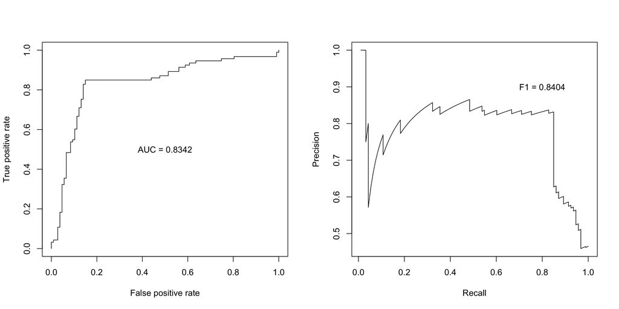

```r
par(mfrow = c(1, 2))
library(ROCR)
data(ROCR.simple)
pred <- prediction(ROCR.simple$pred, ROCR.simple$labels)

# ROC curve
perf <- performance(pred, "tpr", "fpr")
plot(perf)
perf <- performance(pred, "auc")
auc <- perf@y.values[[1]]
text(0.5, 0.5, paste0("AUC = ", round(auc, 4)))

# PR curve
perf <- performance(pred, "prec", "rec")
plot(perf)
id <- which.max(abs(perf@x.values[[1]] + perf@y.values[[1]]))
P <- perf@x.values[[1]][id]
R <- perf@y.values[[1]][id]
F1 <- 2 / (1/P + 1/R)
text(0.8, 0.9, paste0("F1 = ", round(F1, 4)))
```

# 多重检验问题（Con’t）

在多重检验下的p值调整：

- **Family-wise error rate (FWER)**：针对多个零假设 $H_{01},\dots,H_{0N}$, 有多个p值$p_1,\dots,p_N$，FWER定义为
  $$\mathbb P(\text{拒绝任一原假设}\mid\text{所有}~N~\text{个原假设都成立}).$$
  如果$p_i<\alpha/N (i=1,\dots,N)$，则FWER可以在水平$\alpha$下被控制——称这种方法为**Bonferroni修正**.
- **False discovery rate(FDR)**：在被拒绝的假设下的期望错误发现的比例。通常做法是对p值进行排序而拒绝那些满足$p_{(k)}\leq k\alpha/N$的假设。这样FDR就被控制在水平$\alpha$下——称这种方法为**FDR修正**。

```r
p <- sort(c(0.01, 0.01, 0.02, 0.05, 0.05, 0.5))
n <- length(p)
p.adj1 <- p/(1:n)*n
p.adj2 <- p.adjust(p, method = "fdr")
rbind(p.adj1, p.adj2)
```

```
       [,1] [,2] [,3]  [,4] [,5] [,6]
p.adj1 0.06 0.03 0.04 0.075 0.06  0.5
p.adj2 0.03 0.03 0.04 0.060 0.06  0.5
```

# 后记

本文内容参考自中国科学技术大学《统计计算》（2022Fall）课件。

如对本文内容有任何疑问，请联系 watthu@mail.ustc.edu.cn。